# An introduction to plotnine.

Denis Puthier

2018-12-17

# About plotnine

When doing descriptive statistics we frequently need to partition the graphics based on categorical (*i.e.* qualitative) or ordinal variables. Doing such graphics may be particularly difficult when using classical Python graphical libraries (*e.g* matplotlib). The **R** software benefits from a very nice library for such a task, the **ggplot2** package developed by *Hadley Wickham* (Wickham 2016) This package has been quickly became really popular in the bioinformatic field (here categories may be gene, groups of genes, species, signaling pathways, epigenetic marks…) and ordinal variables a discretized level of expression, for instance. The ggplot2 R package is an implementation of the graphical model proposed by *Leland Wilkison* in his book: **The Grammar of Graphics** (Wilkinson 2016). In this model, the graph is viewed as an entity composed of *data*, *layers*, *scales*, *coordinate system* and facets. One can create a graphic then add the various component using the **+** operator. Although the syntax may appear a little bit tricky for beginners, one can quickly understand the benefit of such an approach when composing complexe diagrams.

Several projects have proposed a port of **ggplot2** under **Python**. The **plotnine** library is one of these projects that proposes a rather stable and exhaustive port of **ggplot2** under Python. In the subsequent tutorial, we will use the **chickwts** dataset that is available in the R **datasets** library. We will propose this dataset through an URL available for download. The information we have about the **chickwts** dataset are the following:

**Chicken Weights By Feed Type:** An experiment was conducted to measure and compare the effectiveness of various feed supplements on the growth rate of chickens.

# Downloading the dataset

We will download the dataset (a tabulated flat file) and load it into a **pandas** DataFrame. The **DataFrame¨** object is also a port from a popular object in the R world (**data.frame**). This DataFrame can be viewed as a matrix whose columns may be of various types (Objects, int64, floats…). The DataFrame object contains various functions to perform operations on the dataset.

```python
import pandas as pd
## The URL of the dataset
GITHUB_REPO = "https://raw.githubusercontent.com/dputhier/jgb53d-bd-prog_github/master/"
PATH="practicals/intro_ggplot/chickwts.txt"
## Read the dataset into a
chickwts = pd.read_csv(filepath_or_buffer=GITHUB_REPO+PATH, header=0, sep="\t")
print(chickwts)
```

```
##     weight       feed
## 0      179  horsebean
## 1      160  horsebean
## 2      136  horsebean
## 3      227  horsebean
## 4      217  horsebean
## 5      168  horsebean
## 6      108  horsebean
## 7      124  horsebean
## 8      143  horsebean
## 9      140  horsebean
## 10     309    linseed
## 11     229    linseed
## 12     181    linseed
## 13     141    linseed
```

[output cut: 49 more lines]

What about the type of object returned by **pandas.read_csv()** ? What about the types of the columns ?

```python
print(type(chickwts))
```

```
## <class 'pandas.core.frame.DataFrame'>
```

```python
print(chickwts.dtypes)
```

```
## weight     int64
## feed      object
## dtype: object
```

# Creating a basic diagram

## Example with boxplot and violin plots

The boxplot and violin plots can be used to display the distributions of the underlying variables:

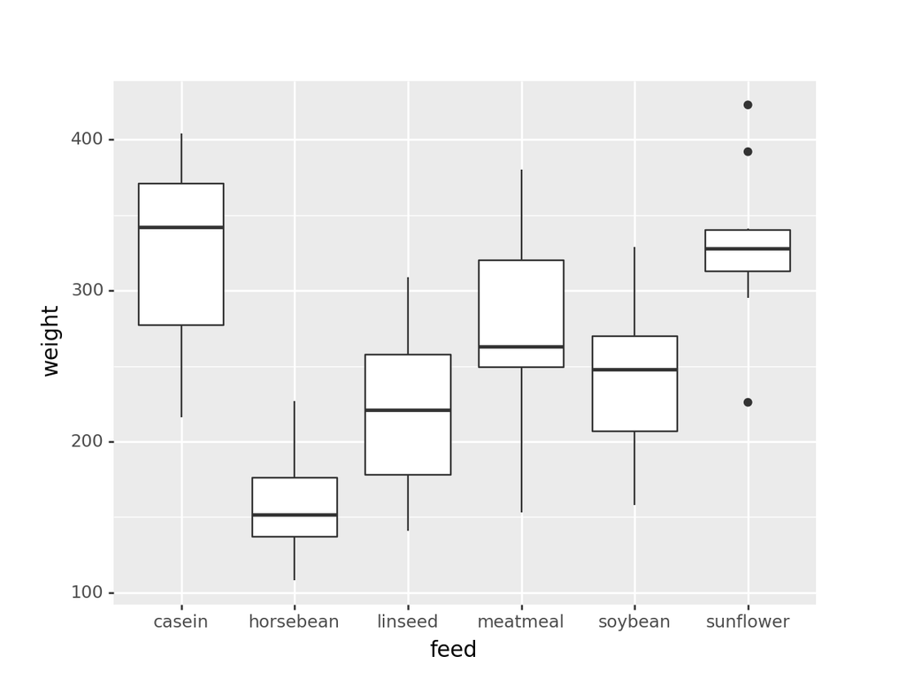

```python
## loading the plotnine package
## Here we load all object enclosed in the package.
## This is useful for analysis but may be harmful
## in a development context
from plotnine import *

## Then we declare a new graphics and associate
## a dataset. Here the aes (aesthetic) argument is set
## to feed and weight.
p = ggplot(data=chickwts, mapping=aes( x='feed', y='weight'))
## We have to indicate the type of requested graphics.
## Here, a boxplot.
print(p + geom_boxplot())
```

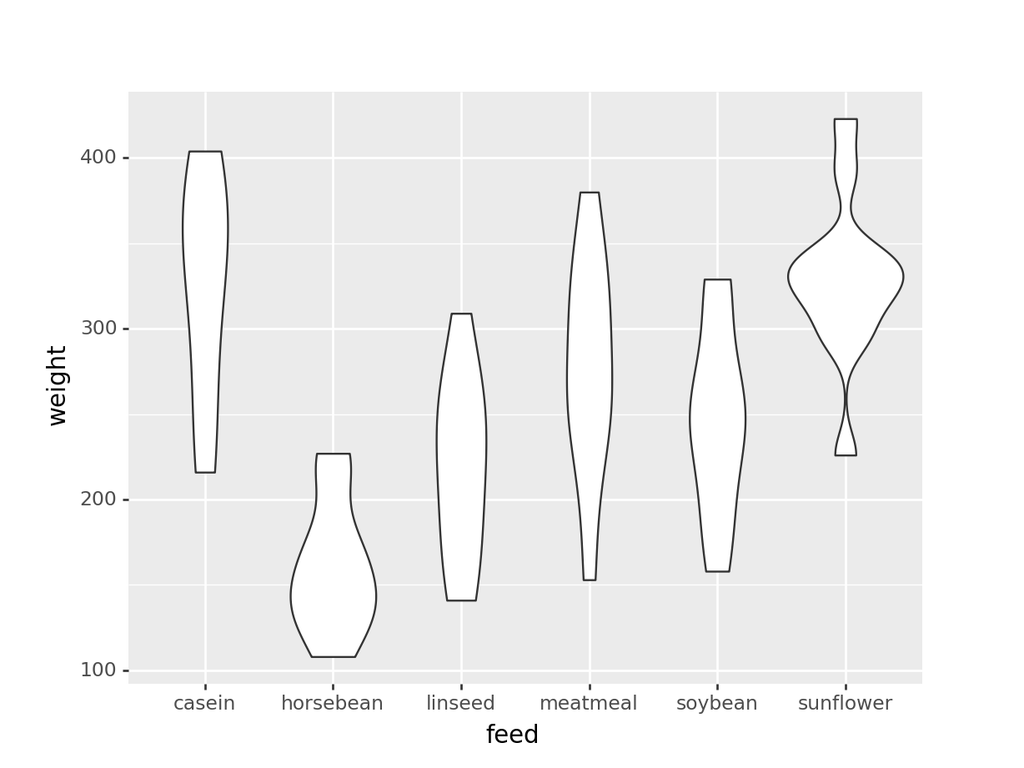

```python
## Now the code for a violin plot
print(p + geom_violin())
```

## Changing the global diagram theme

The diagram theme can be changed using call to functions from plotnine starting with **theme_**.

- Using completion, discover the various functions proposing builtin themes for the diagrams.
- Test some of them to change the global graphic rendering.

<< Hide | Show >>

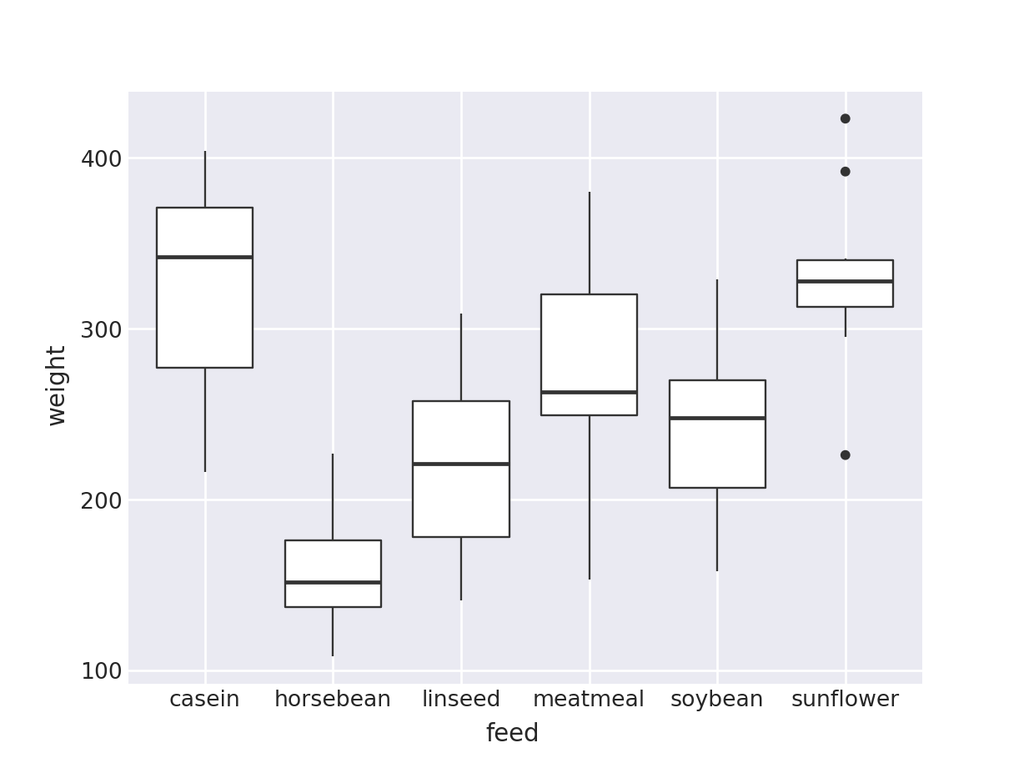

```python
# Using seaborn theme
print(p + geom_boxplot() + theme_seaborn())
```

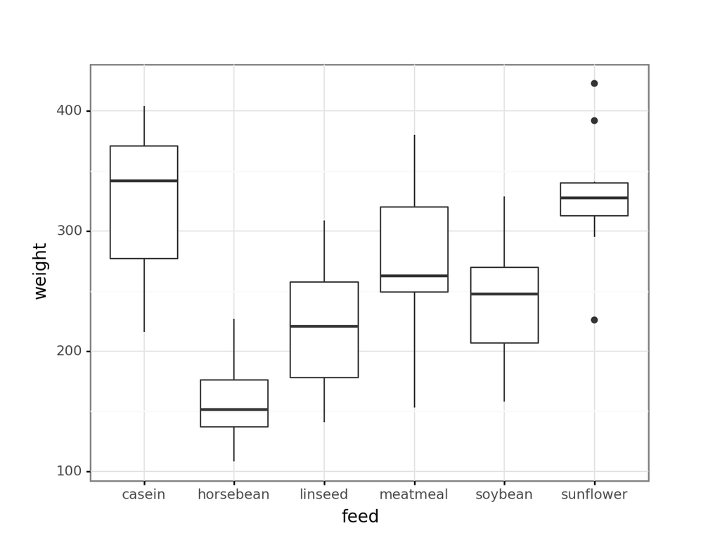

```python
# Using black and white theme (my favorite :))
print(p + geom_boxplot() + theme_bw())
```

## Theming your diagram

The diagrams can be tweaked more deeply by passing some arguments to the **theme()** function. Several aspects of the diagram are thus **themeable**. The list of **themeable** elements is provided [here](https://plotnine.readthedocs.io/en/stable/api.html#themeables). The themeables are objects of several classes:

- element_line – a line.
- element_rect – a rectangle.
- element_text – a text.
- element_blank – no display.

For instance, the following code changes various elements of the theme:

- The axis text.
- The axis title.
- The axis ticks.
- The panel grid.

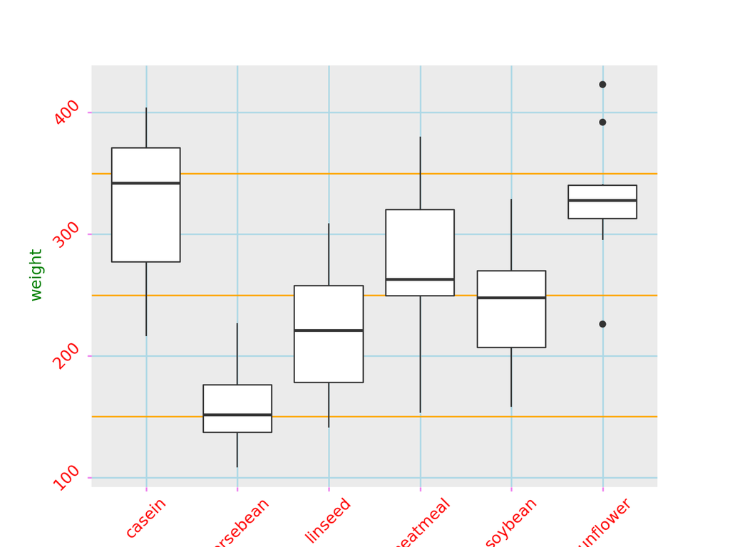

```python
my_plot = p + geom_boxplot() + theme(axis_text=element_text(color='red',size=10,rotation=45),
                           axis_title=element_text(color='green',size=10),
                           axis_ticks=element_line(color='violet',size=20),
                           panel_grid_major=element_line(color='lightblue',size=1),
                           panel_grid_minor=element_line(color='orange',size=1),
                          )
print(my_plot)
```

- Use the themeable elements to create your own boxplot or violin diagram. Think about using html hexadecimal colors such as those proposed on [ColorBrewer web site](http://colorbrewer2.org/).

<< Hide | Show >>

[figure not shown]

```python
# example answer
my_plot = p + geom_boxplot() + theme(axis_text=element_text(color='#e41a1c',size=10,rotation=45),
                           axis_title=element_text(color='#377eb8',size=10),
                           axis_ticks=element_line(color='#4daf4a',size=20),
                           panel_grid_major=element_line(color='#984ea3',size=1),
                           panel_grid_minor=element_line(color='#ff7f00',size=1),
                           plot_background=element_rect(color='#a6cee3',size=2, fill='#a6cee3')

                          )
print(my_plot)
```

## More on aesthetics/mapping

At the moment, we have defined, for a boxplot or violin plot, the categories that should appear on the x axis and the values whose distributions should appear on the y axis. We may also assign additional aesthetics. These additional aesthetics may be ‘fill’ (for the color of the boxes in the boxplot) or the ‘color’ for the colors of the box borders (there are also additional aesthetic depending on the geom function).

If ‘fill’ and ‘color’ are passed to the **geom_boxplot()** this mean that colors should be the same for all boxes.

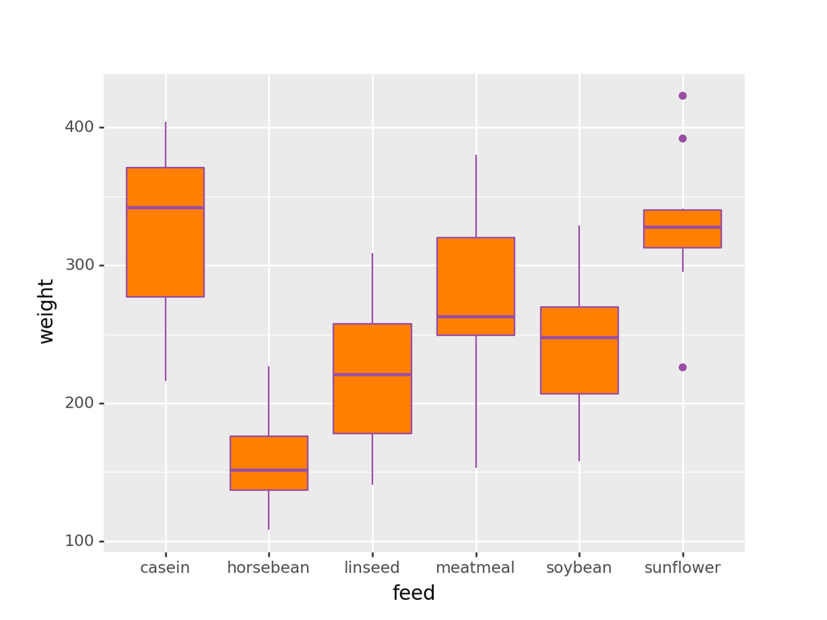

```python
## Then we declare a new graphics and associate
## a dataset. Here the aes (aesthetic) argument is set
## to feed and weight.
my_plot = ggplot(data=chickwts,
          mapping=aes( x='feed', y='weight')) + geom_boxplot(color='#984ea3', fill='#ff7f00')
print(my_plot)
```

Now, another solution is to path ‘fill’ and ‘colors’ to the **aes()** function. In this case it means that we want to change the colors according to the categories found in ‘feed’. This also mean that we need a way to tell plotnine which colors we want to apply as it will just use a set of default colors.

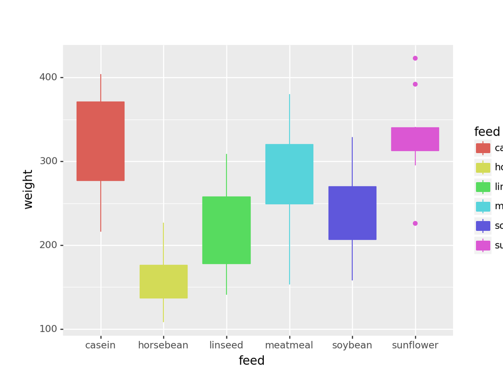

```python
## Then we declare a new graphics and associate
## a dataset. Here the aes (aesthetic) argument is set
## to feed and weight.
my_plot = ggplot(data=chickwts,
          mapping=aes( x='feed', y='weight', color='feed', fill='feed')) + geom_boxplot()
print(my_plot)
```

To change the colors we now need to use the **scale_color_manual()** and **scale_fill_manual()** functions to which we can pass a dictionary containing the classes to colors mapping. Here the classes are the following:

```python
print(pd.Categorical(chickwts['feed']).categories)
```

```
## Index(['casein', 'horsebean', 'linseed', 'meatmeal', 'soybean', 'sunflower'], dtype='object')
```

So we just need to create a dictionnary containing the classes (*i.e* ‘feed’) and the associated colors.

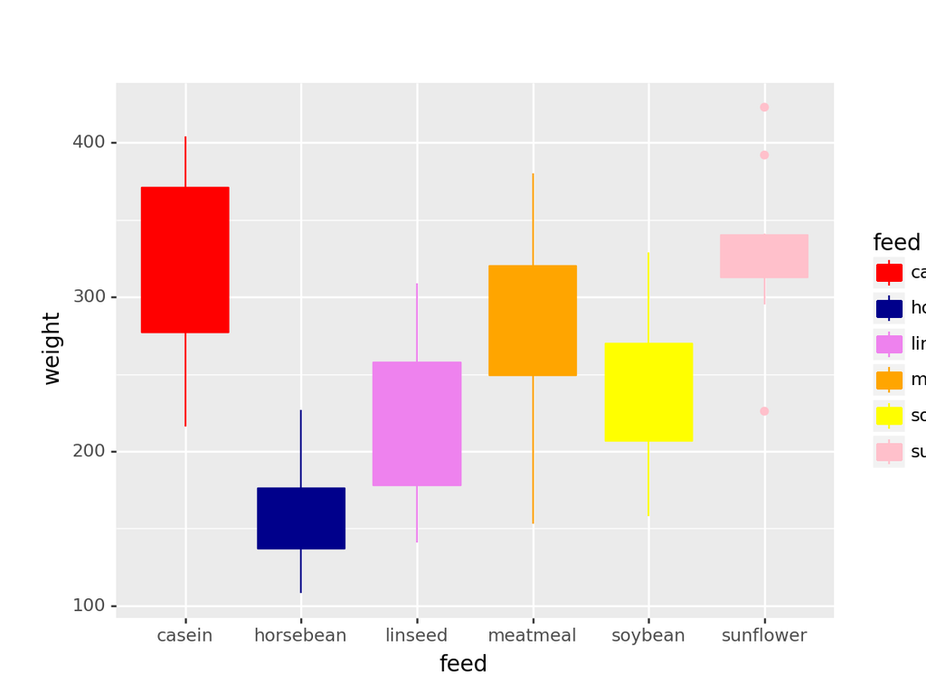

```python
color_dict = {'casein': 'red',
              'horsebean': 'darkblue',
              'linseed': 'violet',
              'meatmeal': 'orange',
              'soybean': 'yellow',
              'sunflower':'pink'}
my_plot = ggplot(data=chickwts,
          mapping=aes( x='feed', y='weight', color='feed', fill='feed')) + geom_boxplot()
my_plot += scale_color_manual(values=color_dict)
my_plot += scale_fill_manual(values=color_dict)
print(my_plot)
```

We may improve this plot by changing the legend attributes.

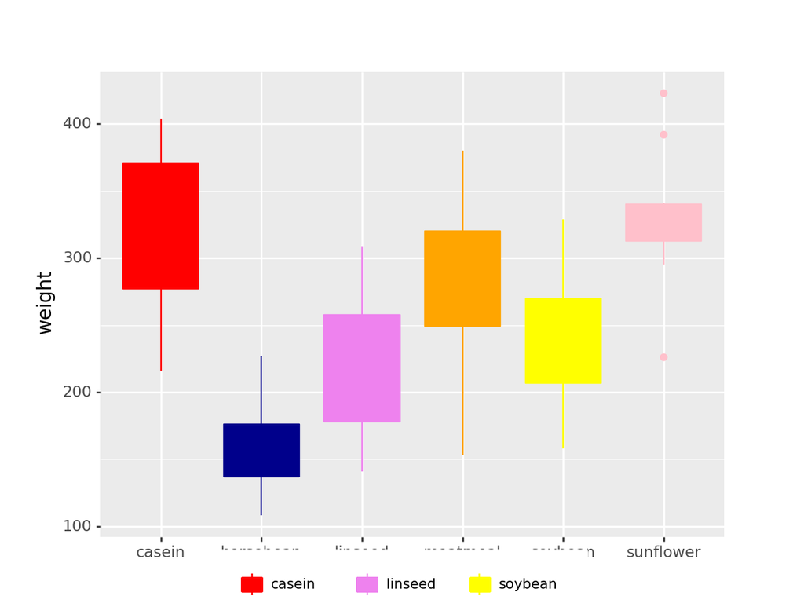

```python
my_plot += theme(legend_position="bottom",
                      legend_text=element_text(size=8),
                      legend_key=element_rect(colour="white", fill="white"),
                      legend_title=element_blank())
print(my_plot)
```

- Create your own violin plot using your own theme.

<< Hide | Show >>

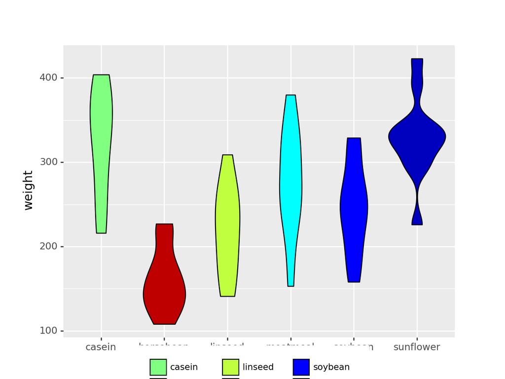

```python
color_dict = {'casein': '#80FF80',
              'horsebean': '#BF0000',
              'linseed': '#BFFF40',
              'meatmeal': '#00FFFF',
              'soybean': '#0000FF',
              'sunflower':'#0000BF'}
my_plot = ggplot(data=chickwts,
          mapping=aes( x='feed', y='weight', fill='feed')) + geom_violin(color='black')

my_plot += scale_fill_manual(values=color_dict)
my_plot += theme(legend_position="bottom",
                      legend_text=element_text(size=8),
                      legend_key=element_rect(colour="white", fill="white"),
                      legend_title=element_blank())
print(my_plot)
```

## Other diagrams

There are about [40 different graphics](https://plotnine.readthedocs.io/en/stable/api.html#geoms) currently available in **plotnine**. The names of the associated functions start with ’geom_*’ (*e.g.* geom_boxplot, geom_tile, geom_text, geom_smooth, geom_rug, geom_hist, geom_bar…).

### Histograms and densities

In the case of histograms, the x axis corresponds to intervals (‘bins’) and the y axis to the number of values falling in the intervals. Thus, there is only one value to pass to **aes()**.

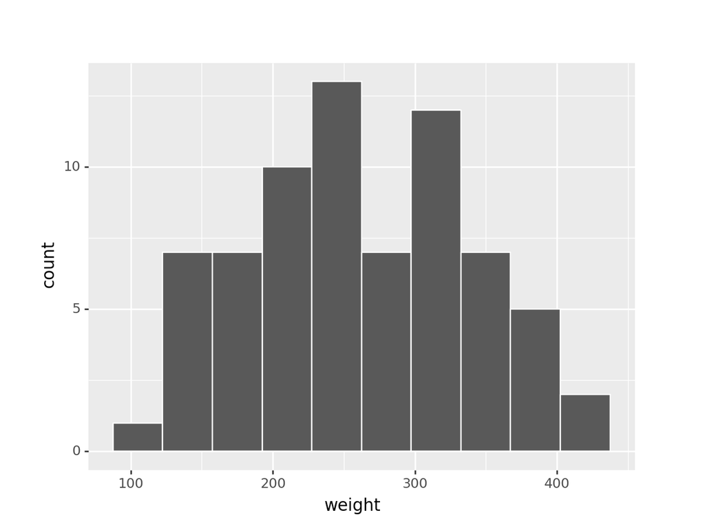

```python
## Here the code for an histogram
my_plot = ggplot(data=chickwts, mapping=aes(x='weight')) + geom_histogram(color='white', bins=10)
print(my_plot)
```

Probability density can be displayed using **geom_density()**. Unfortunatly, the number of data in each class is clearly too limited here. We will see a better example later.

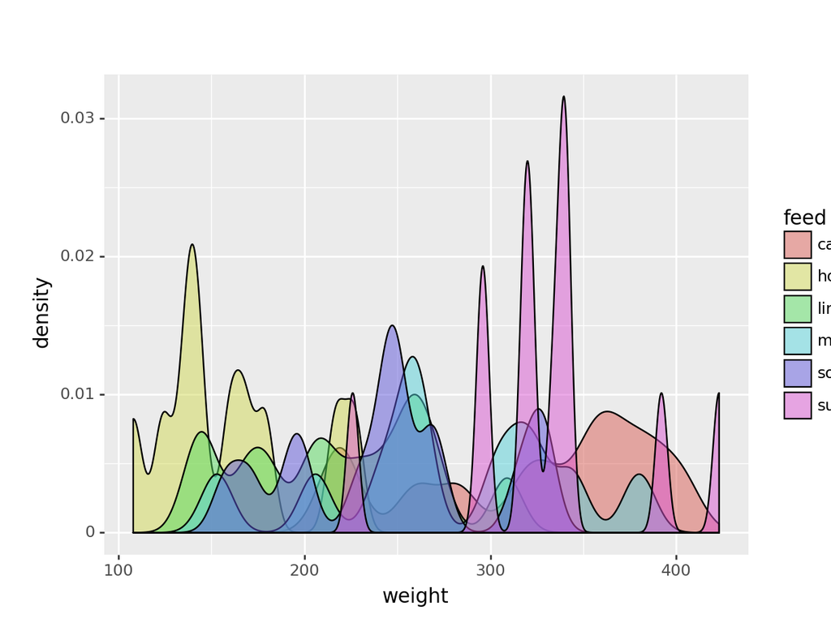

```python
my_plot = ggplot(data=chickwts, mapping=aes(x='weight', fill='feed')) + geom_density(adjust = 1/4, alpha=0.5)
print(my_plot)
```

## Overlaying diagrams

One can overlay several diagrams of various types very easily, just using the ‘+’ operator. For instance one can first create a simple scatterplot using **geom_point()**.

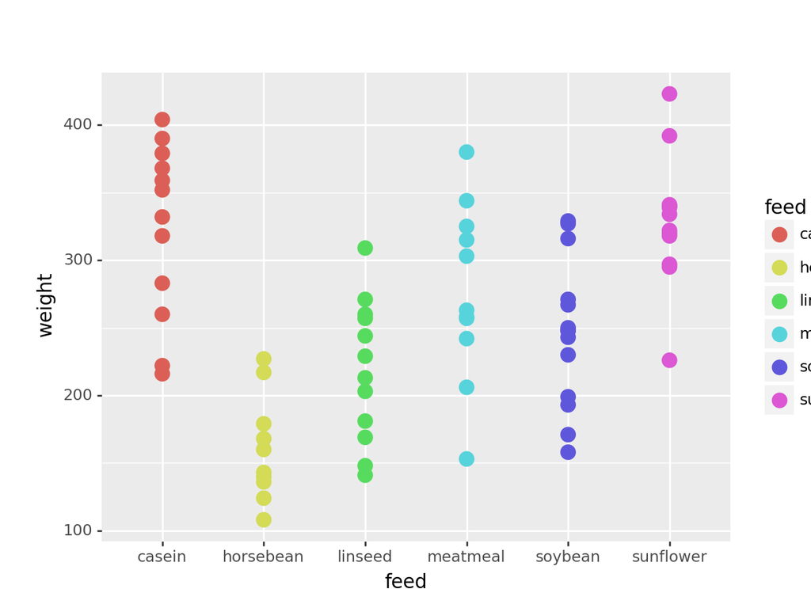

```python
## We can, for instance, show the values associated to each feed
my_plot = ggplot(data=chickwts,
          mapping=aes( x='feed', y='weight', fill='feed', color='feed')) + geom_point(size=4)
print(my_plot)
```

However as they are some ties it may be advised to use the **geom_jitter()** function that will add some randomness to the value of the x axis (that here are categorical but can be viewed as 1, 2, 3…)

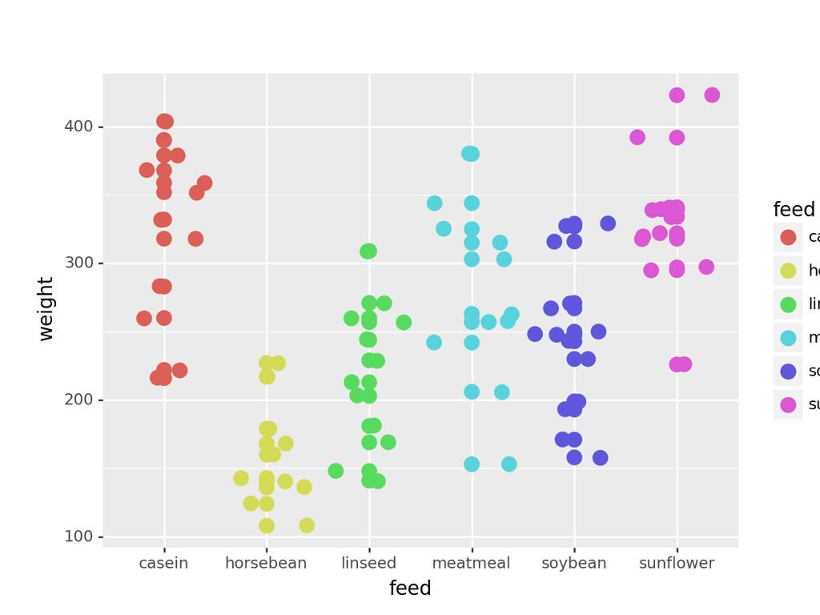

```python
my_plot += geom_jitter(size=4)
print(my_plot)
```

As diagrams can be viewed as layers, we may also add a **geom_rug()** layer.

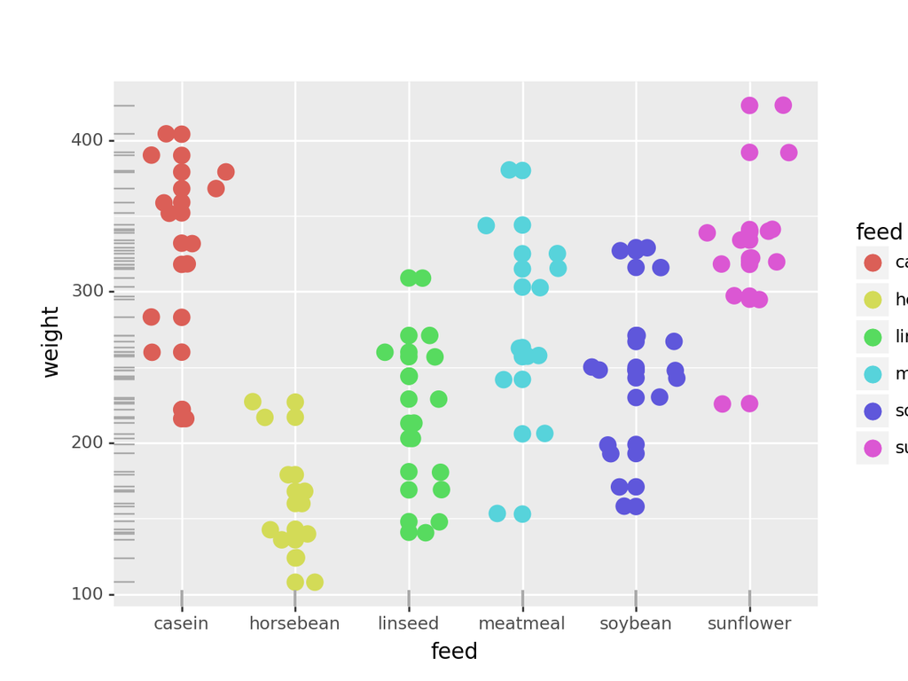

```python
my_plot += geom_rug(color='darkgrey')
print(my_plot)
```

# Partitioning graphics using facets

Partitioning the diagram based on a given factor/variable allows one to explore deeply the dataset. For the following example, we will create a matrix containing the results of an artificial ELISA experiment in which several measures done at two different times and by four different researchers are recorded.

## Loading the dataset

```python
URL = "https://tinyurl.com/ycdhmof8"
elisa = pd.read_csv(filepath_or_buffer=URL, header=0, sep="\t")
elisa.head()
```

The column names of the DataFrame are the following:

```python
elisa.columns.tolist()
```

The number of elements:

```python
# Number of rows
elisa.shape[0]
# Number of columns
elisa.shape[1]
```

These are ELISA plates so each of them contains 96 elements.

```python
elisa.groupby(['day','user']).size()
```

[output not shown]

## Facetting

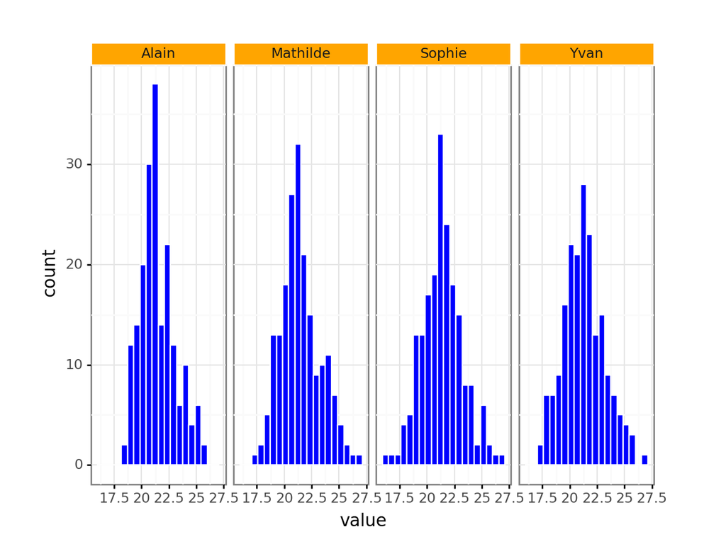

```python
my_plot = ggplot(data = elisa, mapping = aes(x='value'))
my_plot += geom_histogram(fill="blue", color="white", bins=20)
my_plot += theme_bw()
my_plot += theme(strip_background = element_rect(colour = "white", fill="orange"))
print(my_plot + facet_grid(facets = '~ user'))
```

Interestingly, one can also easily create facets based on two variables, here user and days:

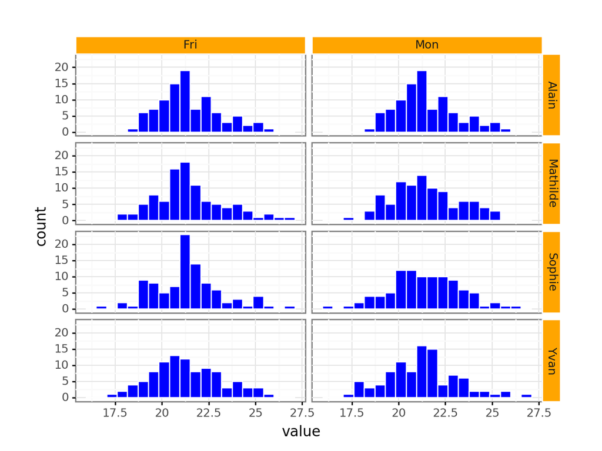

```python
print(my_plot + facet_grid(facets = 'user ~ day'))
```

Or alternatively…

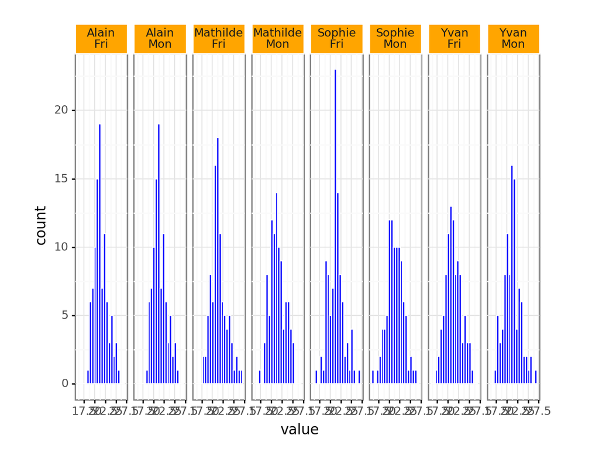

```python
print(my_plot + facet_grid(facets = '~ user + day '))
```

Or even

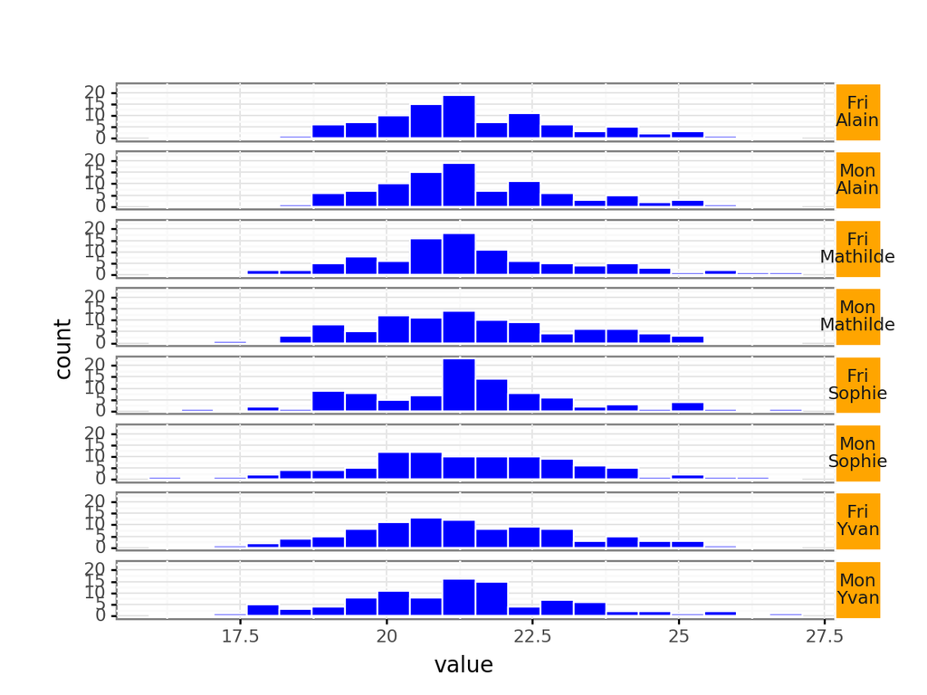

```python
print(my_plot + facet_grid(facets = 'user + day ~') + theme(strip_text = element_text(rotation=0)))
```

# Creating heatmaps

As we are working with an artificial ELISA dataset, it can be interesting to reproduce a color-coded image of the ‘original’ ELISA plates. The **geom_tile()** function can be used to create heatmaps.

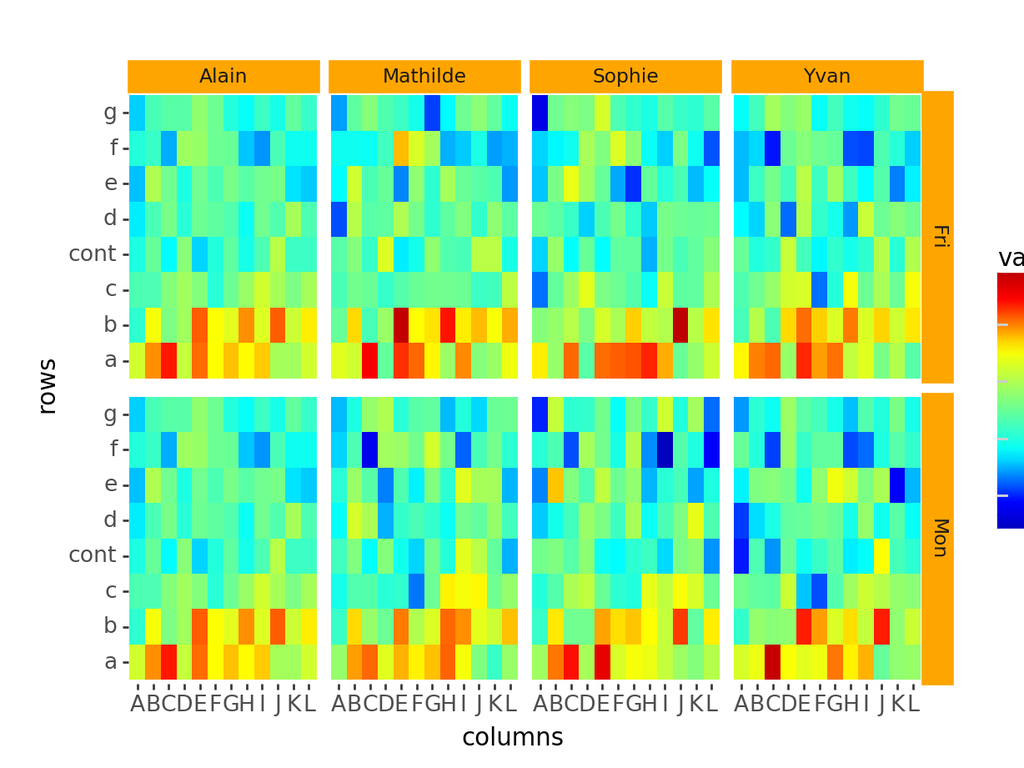

```python
my_plot = ggplot(data = elisa, mapping = aes(x='columns', y='rows', fill='value'))
my_plot += geom_tile()
my_plot += theme(axis_text_x = element_text(size = 10),
                 axis_text_y = element_text(size = 10),
                 panel_background = element_rect(fill="white"),
                 panel_grid_major = element_line(colour = "white"),
                 strip_background = element_rect(colour = "orange", fill="orange"))
my_plot +=   scale_fill_gradientn(colors = ["#0000BF", "#0000FF",
                                              "#0080FF", "#00FFFF",
                                              "#40FFBF", "#80FF80",
                                              "#BFFF40", "#FFFF00",
                                              "#FF8000", "#FF0000",
                                              "#BF0000"])
print(my_plot + facet_grid(facets = 'day ~ user'))
```

# Practical 1 (About processed pseudogenes)

## The dataset

Here, our dataset contains several informations related to transcripts in the human genome. They were computed using *pygtftk* (v0.9.8) from a GTF file downloaded from ensembl (genome version GRCh38, release 92). First we will load the dataset, set the row names to the transcript ids and inspect the column names.

```python
## The URL pointing to the dataset
URL = "https://tinyurl.com/hg38-tx-info-txt"
## Read the dataset into a pandas DataFrame
## The transcript names are located in column 11 (10 in zero-based)
## The first line (0 in zero-based) is the header
tx_info = pd.read_csv(filepath_or_buffer=URL, header=0, sep="\t", index_col=10)
```

- What is the type of tx_info ?
- How many lines does the dataset contain ?
- How many columns ?
- What are the columns names ?
- How many chromosomes are defined ? You can access columns using tx_info[‘column_name’].
- How many different transcripts ? The row names can be found in the ‘.index’ attributes of the DataFrame.
- How many gene can be found in the dataset ? Use the gene_id column.
- What are the possible values for ‘gene_biotype’ ?

<< Hide | Show >>

```python
# What is the type of tx_info ?
print(type(tx_info))
```

```
## <class 'pandas.core.frame.DataFrame'>
```

```python
# How many lines does the dataset contain ?
print(tx_info.shape[0])
```

```
## 178654
```

```python
# How many columns ?
print(tx_info.shape[1])
```

```
## 31
```

```python
# What are the columns names ?
# or in a more readable way: sorted(tx_info.columns)
print(sorted(tx_info.columns.tolist()))
```

[output not shown]

```python
# How many chromosomes (seqid) are defined ?
set(tx_info['seqid'].tolist())
```

```python
# How many different transcripts ?
len(set(tx_info.index.tolist()))
```

```python
# How many gene can be found in the dataset ?
len(set(tx_info['gene_id'].tolist()))
```

```python
# What are the possible values for 'gene_biotype' ?
set(tx_info['gene_biotype'].tolist())
```

## Subseting the dataset

In the subsequent analysis we will only focus on transcript classes (‘gene_biotype’) for which at least 500 transcripts are found.

```python
tx_info = tx_info.groupby('gene_biotype').filter(lambda x: len(x) > 500)
set(tx_info.gene_biotype)
```

## Splitting gene categories on several lines

```python
tx_info.gene_biotype = [x.replace("_", "\n") for x in tx_info.gene_biotype]
```

## Looking at transcript length and the case of processed pseudogene

- Explore the transcript genomic length (‘tx_genomic_size’, size of exons plus introns) variable. What can you say about the distributions of transcript genomic length regarding chromosome and gene_biotype ? You can use **geom_density()** or **geom_histogram()** for graphical display.
- What about the size of **processed pseudo-genes** ? How may one explain this difference ?

<< Hide | Show >>

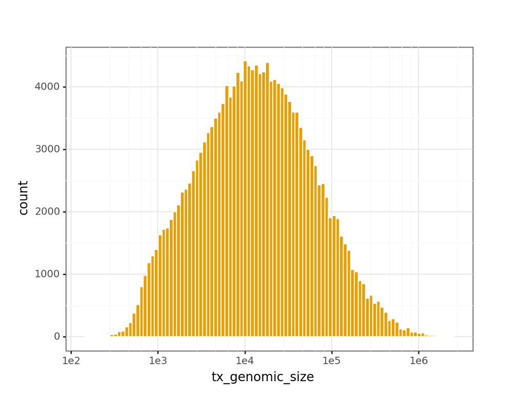

```python
## The global distribution
my_plot = ggplot(data=tx_info, mapping=aes( x='tx_genomic_size'))
my_plot += geom_histogram(bins=100, fill="#E69F00", color="white")
my_plot += scale_x_continuous(trans='log10')
my_plot += theme_bw()
print(my_plot)
```

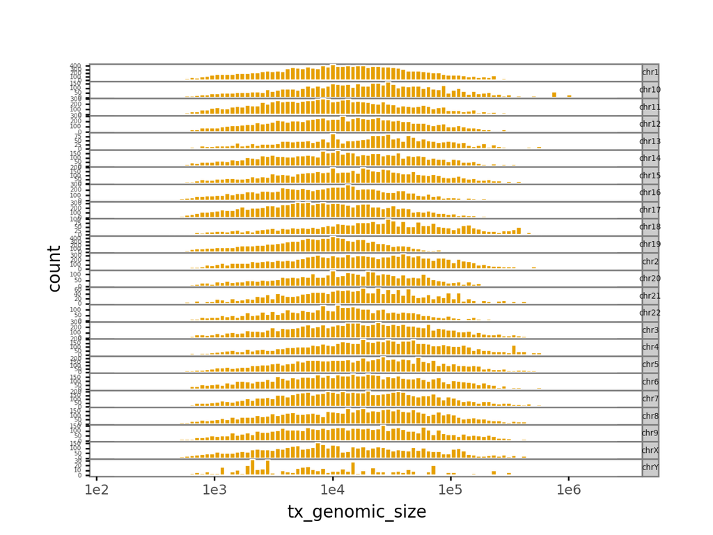

```python
## The distribution faceted by chromosomes
## There seems not to be any particular association between
## Chromosomes and transcript length
print(my_plot + facet_grid('seqid~', scales="free_y") + theme(strip_text=element_text(rotation=0, size=5), panel_grid=element_blank(), axis_text_y=element_text(size=4), panel_spacing=0))
```

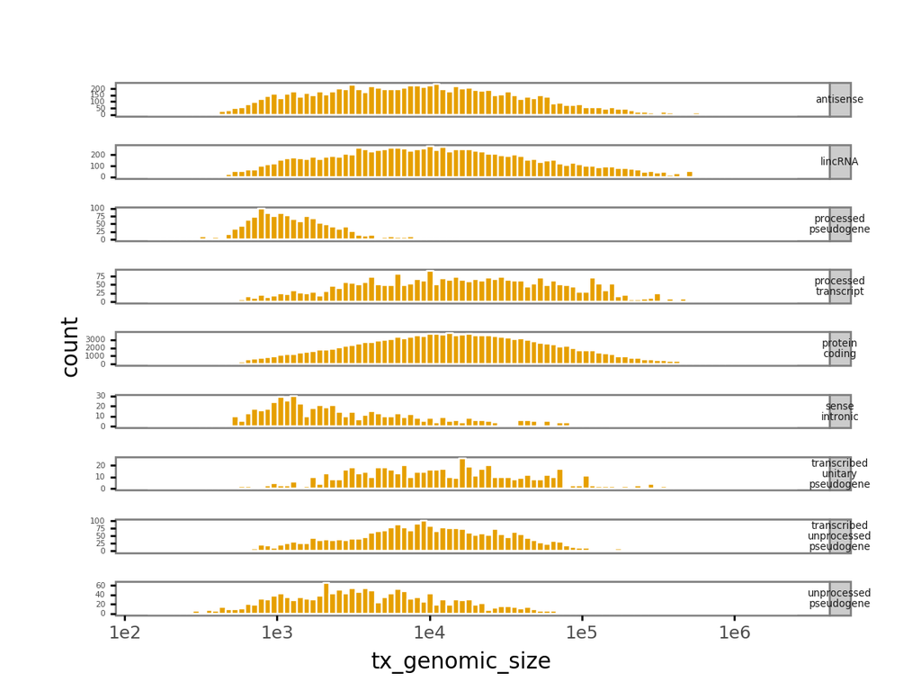

```python
## The distribution faceted by chromosomes
## There seems not to be any particular association between
## Chromosomes and transcript length
print(my_plot + facet_grid('gene_biotype~', scales="free_y") + theme(strip_text=element_text(rotation=0, size=5), panel_grid=element_blank(), axis_text_y=element_text(size=4), panel_spacing=0.2))
```

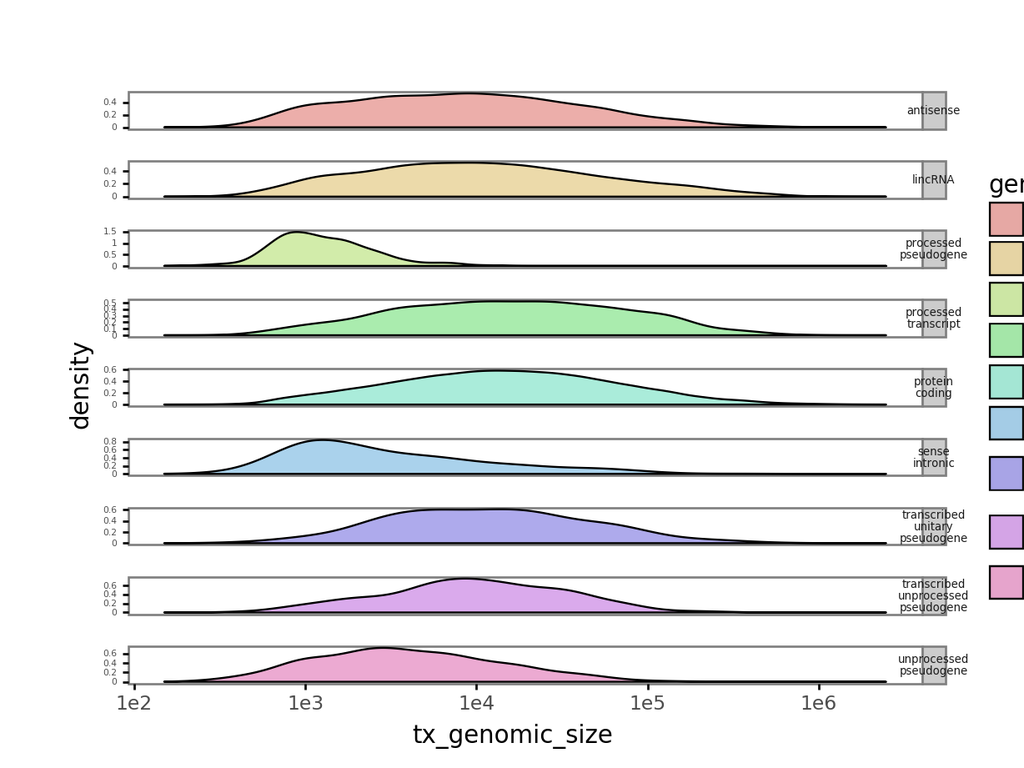

```python
## The distribution faceted by chromosomes
## can be viewed alternatively using a density
my_plot = ggplot(data=tx_info, mapping=aes( x='tx_genomic_size', fill='gene_biotype'))
my_plot += geom_density(alpha=0.5)
my_plot += scale_x_continuous(trans='log10')
my_plot += theme_bw()
my_plot += theme(strip_text=element_text(rotation=0, size=5), panel_grid=element_blank(), axis_text_y=element_text(size=4), panel_spacing=0.2)
my_plot += facet_grid('gene_biotype~', scales="free_y")
print(my_plot)
```

- Now, what can you say about the number of exons for transcripts depending on ‘gene_biotype’ ? Use a proper graphic to display this information.
- What can we say about **processed pseudo-genes** ? Is that expected ?

<< Hide | Show >>

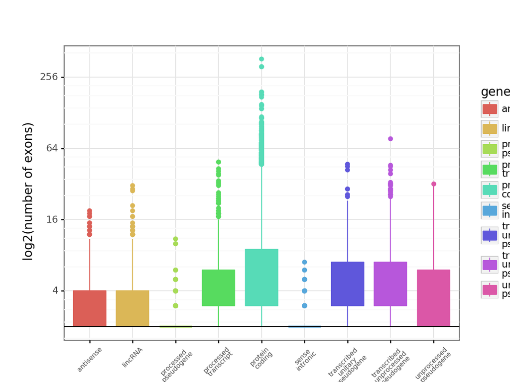

```python
## The global distribution
my_plot = ggplot(data=tx_info, mapping=aes( x='gene_biotype', y='nb_exons', fill='gene_biotype', color='gene_biotype'))
my_plot += geom_boxplot()
my_plot += scale_y_continuous(trans='log2')
my_plot += theme_bw()
my_plot += ylab('log2(number of exons)')
my_plot += theme(axis_text_x=element_text(size=6, rotation=45),
                panel_grid_minor=element_line(size=1))
my_plot += geom_abline(intercept = 1, slope=0)
print(my_plot)
```

For the next diagrams we will order the chromosome from 1 to 22 then X, Y. Plotnine doesn’t know about the chromosomes order. By default it will just display them the way they were encountered. However, we can define the order of a qualitative variable. To this aim we need to use *pd.Categorical()* that can change a dataframe column so that it becomes a categorial variable that can even be ordered (ordinal variable):

```python
## Define an ordinal variable
chrom_list = ["chr" + str(x) for x in range(1,23) ]
chrom_list += ['chrX', 'chrY']
tx_info.seqid = pd.Categorical(tx_info.seqid.tolist(), categories=chrom_list, ordered=True)
## The categories are know part
## of the column definition
print(tx_info.seqid.head())
```

```
## transcript_id
## ENST00000456328    chr1
## ENST00000450305    chr1
## ENST00000488147    chr1
## ENST00000473358    chr1
## ENST00000469289    chr1
## Name: seqid, dtype: category
## Categories (24, object): [chr1 < chr2 < chr3 < chr4 ... chr21 < chr22 < chrX < chrY]
```

- What can you say about the distribution of each gene biotype across chromosomes (*i.e* the number of each category per chromosome). Draw a barplot (**geom_bar**) showing the number of transcripts from each gene_biotype class on each chromosome. Use **geom_bar** with argument **position** set to ‘stack’, ‘dodge’ or ‘fill’. depending on this argument, do you get the same feeling about the way the distribution of gene biotype across the chromosomes. What are the pros and cons of each representation ?
- What can we say about ‘processed pseudogene’ ?
- What is another intriging feature of the Y chromosome ?

<< Hide | Show >>

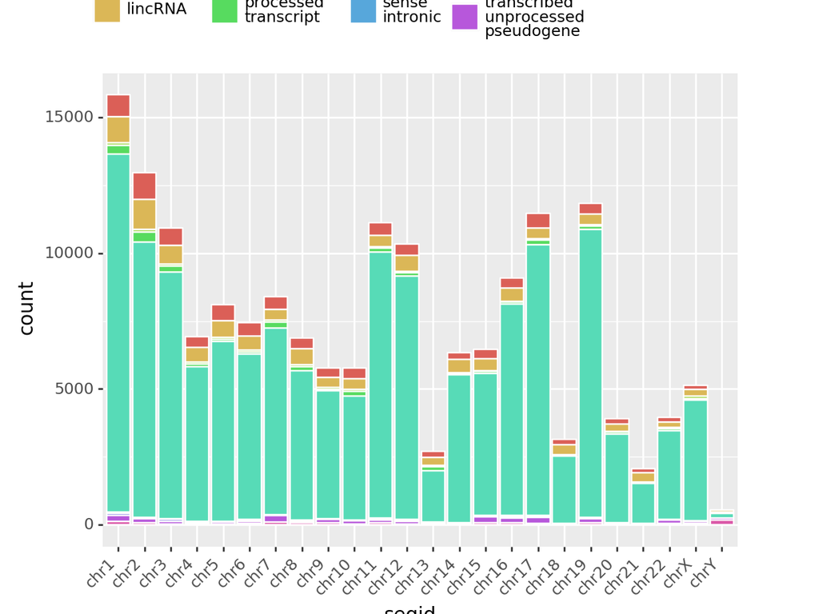

```python
# geom bar with position "stack"
my_plot = ggplot(tx_info, aes(x='seqid', fill='gene_biotype', label='stat(count)'))
my_plot +=   theme(axis_text_x = element_text(angle = 45, hjust=1),
                   strip_text_x = element_text(size = 7,  colour = 'black', angle = 90),
                   legend_position='top')
print(my_plot + geom_bar(color="white", position='stack'))
```

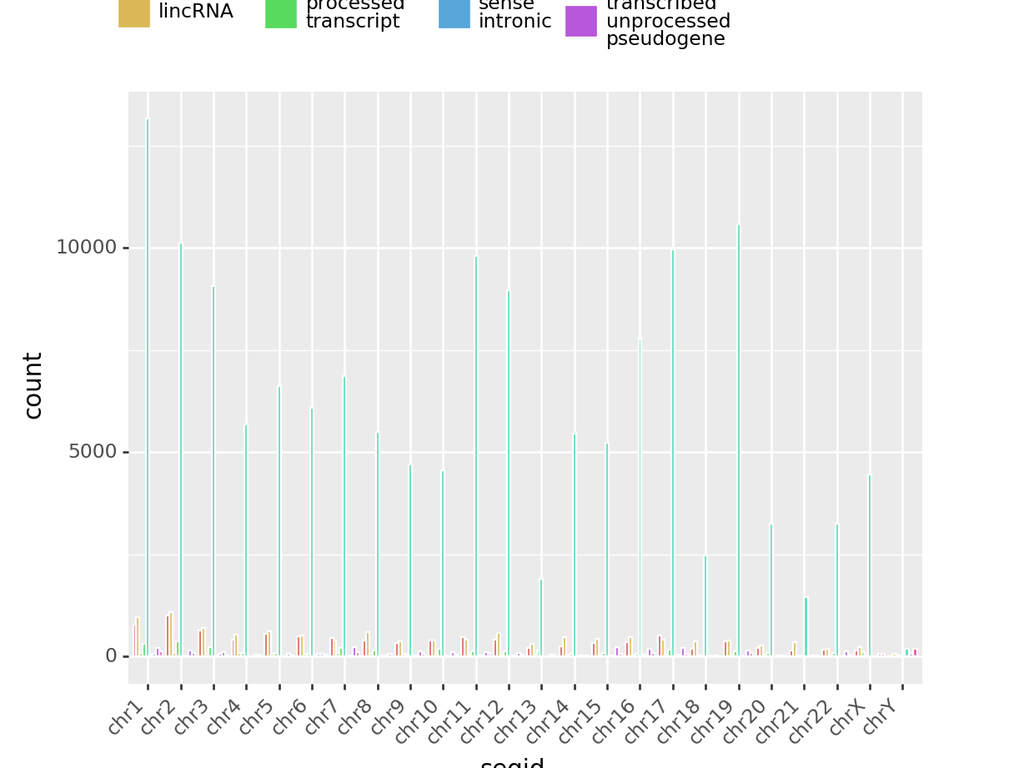

```python
# geom bar with position "dodge"
print(my_plot + geom_bar(color="white", position='dodge'))
```

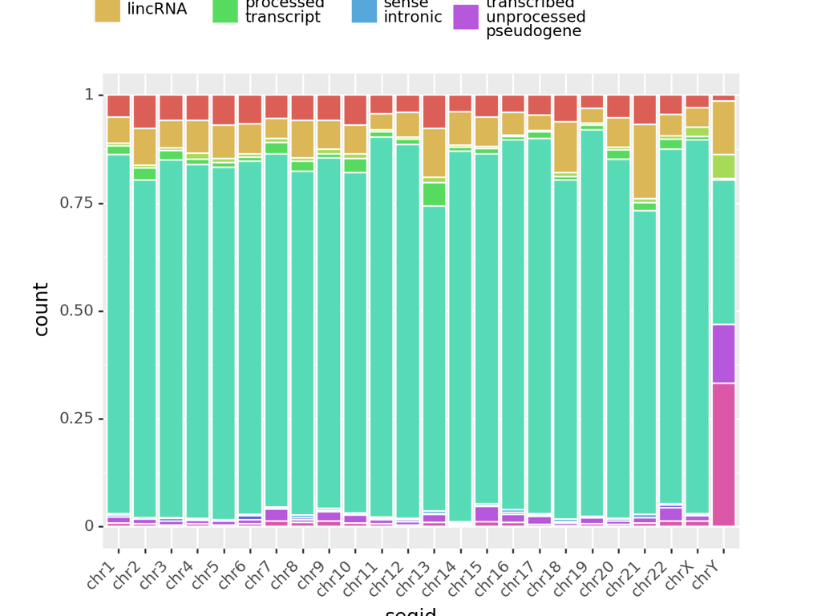

```python
# geom bar with position "fill"
print(my_plot + geom_bar(color="white", position='fill'))
```

Wickham, Hadley. 2016. *Ggplot2: Elegant Graphics for Data Analysis*. Springer-Verlag New York. http://ggplot2.org.

Wilkinson, Leland. 2016. *The Grammar of Graphics (Statistics and Computing) 2nd Edition*. Springer.